# project_4_explanation slides

## Project 4 - Student Loan Data

1. Basic Loan Information
2. Trends with Risk Assessment Score
3. Loan Rate and Credit Score
4. Monthly Payment and Loan Amount
5. Conclusion

## 1. Basic Loan Information

- Loan APR
- Loan Amount
- Loan Term
- Borrower Credit Score
- Borrower Risk Assessment Score

Median values are indicated by red lines.

*Note: Section 1, has information for about 114,000 loans, this is the whole dataset. Sections 2 and beyond only have around 87,000 entries. This is because the way risk is measured was changed during 2009, leading to two different risk scores, that are not comparable. Since 2009, most of the data entries are present, so this is the part of the dataset that I will be reporting on.

### Loan Annual Percentage Rate

Loan APRs range from 0.0065% up to 0.51%, with a median value of 0.21%.

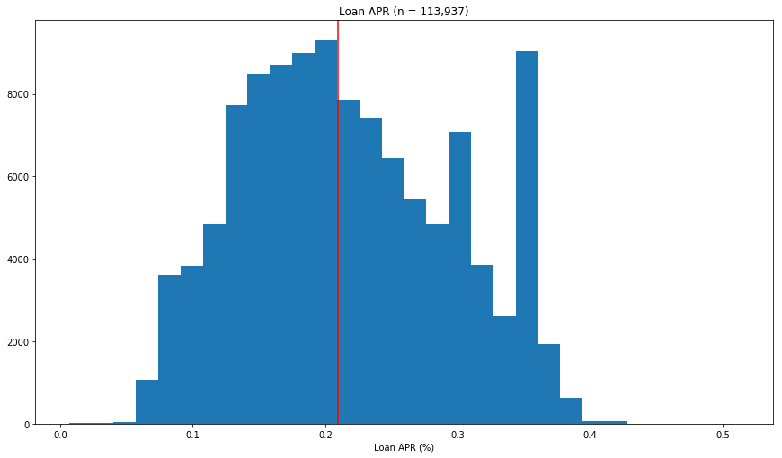

### Loan Amount

Amounts borrowed range from \$1,000 to \$35,000, with a median amount of \$6,500.

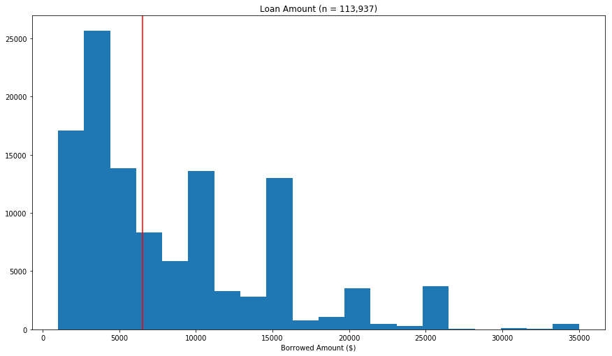

### Loan Term (length)

- 77% are 36 months
- 22% are 60 months
- 1% are 12 months

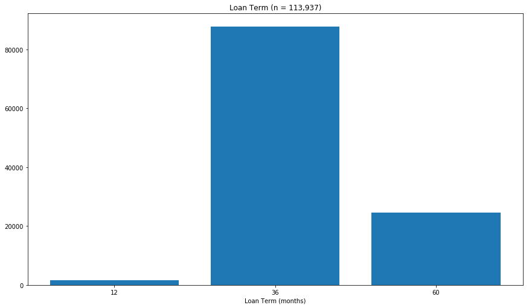

### Credit Score*

The credit scores range from 360 up to 880, with a median credit score of 680.

*Note: The data reports two credit score values, a 'lower' and an 'upper' value. Every 'upper' value is +19 points above the corresponding 'lower' value. The reported values here are the 'lower' values.

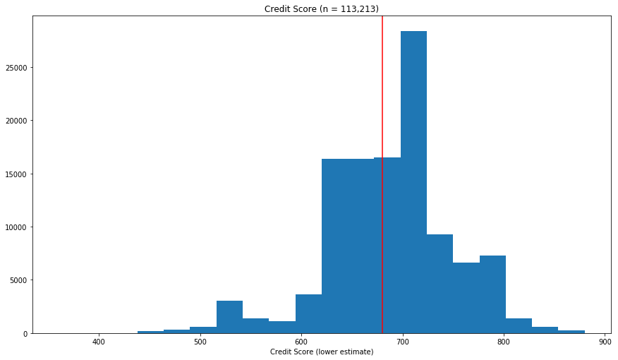

### Risk Assessment Score

Risk assessment scores go from 1 (highest risk) up to 11 (lowest risk). The median value is 6.

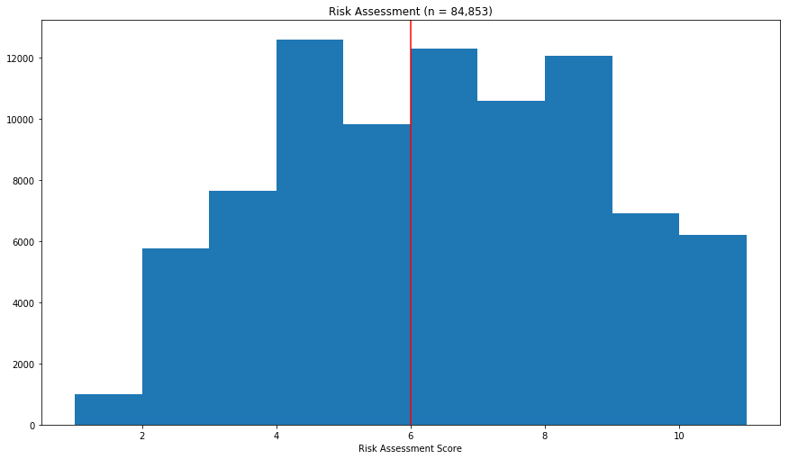

### Importance of Loan Rate

Loan Rate is very important, as a higher rate means you are required to pay back more money, above what you borrowed, for the ability to borrow that money. The lending institution gives a Risk Assessment Score to every borrower. This number is used to gage the loan risk and to set up loan conditions so that the lender minimizes its risk.

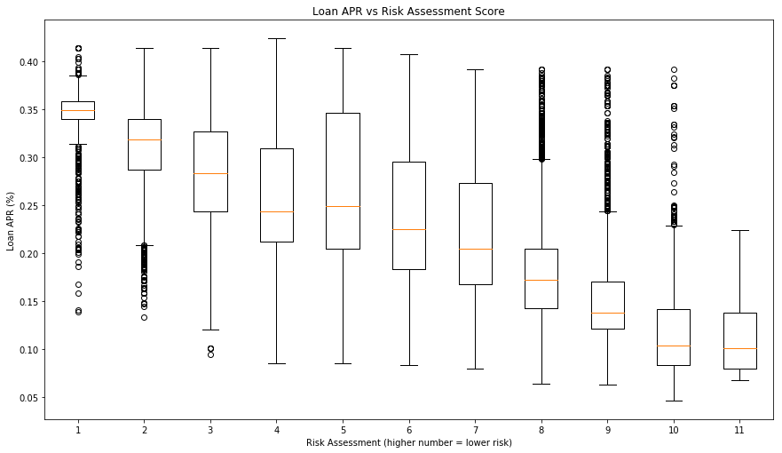

### Importance of Loan Rate (cont.)

From the previous graph, the median Loan Rate trend is clearly correlated with Risk Assessment Score. With a Risk Score of 1, the median loan rate is 0.35%. Loans with a Risk Score of 10 or 11 have a median rate of 0.10%, 3.5 times lower. Comparing a loan with a Risk Score of 10 or 11 to an average risk loan (6), the higher risk score gives a loan rate of half.

## 2. Trends with Risk Assessment Score

- Credit Score
- Homeownership

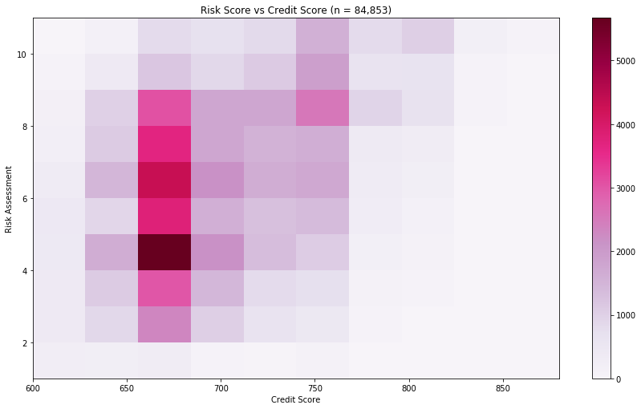

### Risk Score and Credit Score

The linear regression shows the trend between Risk Score and Credit Score, as positive. There are many cases of individuals having a high credit score and recieving a low risk score (considered higher risk). And there are examples of the opposite occuring, but the trend is clear.

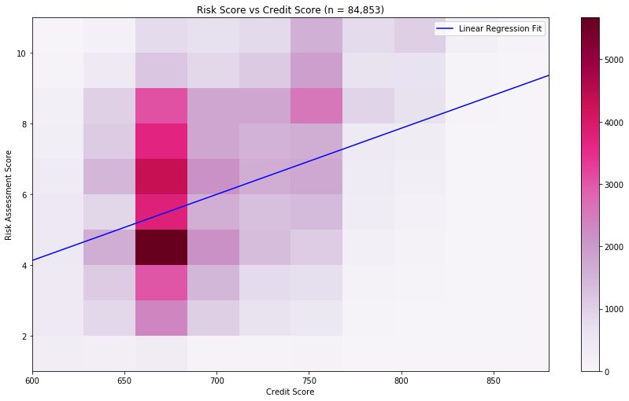

### Credit Score and Homeownership

Lending institutions might see homeownership as a positive, indicating that they are more likely to be able to payback their loan. From the next graph, the median credit score of a homeowner is 700, compared to 680 of non-homeowners.

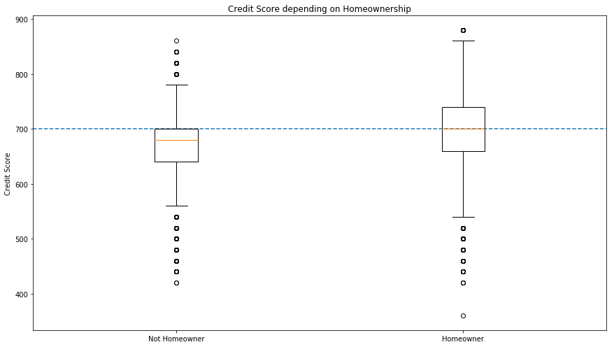

## 3. Loan Rate and Credit Score

- Graph
- Linear Regression

### Loan Rate and Credit Score

One would expect that, on average, a person with a higher credit score would be able to get a lower loan rate.

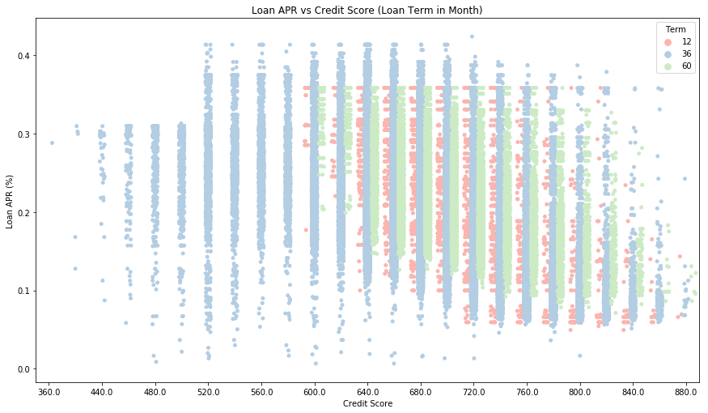

### Loan Rate and Credit Score (cont.)

Loan Rate and Credit Score have an inverse relationship. There are cases that stray from the expected, but the trend is clear. There are other factors that determine a loan rate, other than credit score, but it is an important factor.

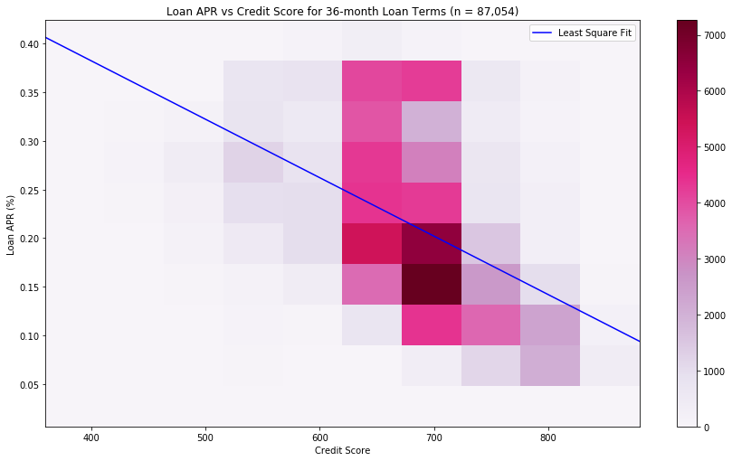

## 4. Monthly Payment and Loan Amount

- Monthly Payment vs Loan Amount, with Term Length
- Monthly Payment vs Loan Amount, with Loan APR

### Monthly Payment, Loan Amount, Term Length

Three distinct cases emerge from the graph, one for each term length. It makes sense that as the loan amount increases that the corresponding monthly payments also increase. Also, as the term length increases (lighter in color), for a constant loan amount, that the monthly payments also decrease.

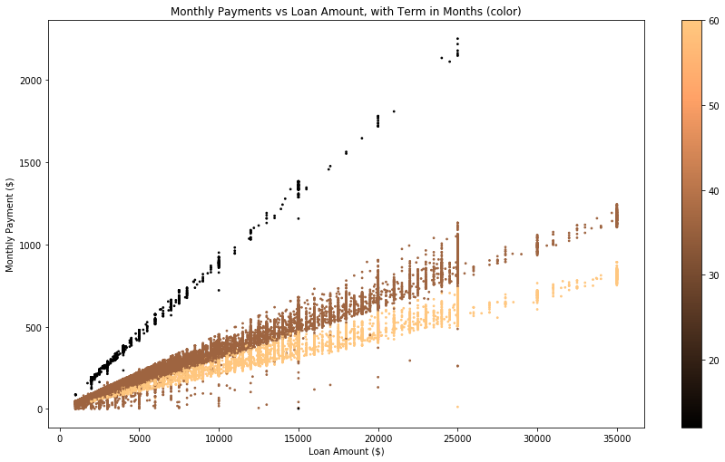

### Monthly Payment, Loan Amount, Loan APR

For a given loan amount, the lower the loan rate (darker in color), the lower the monthly payments are.

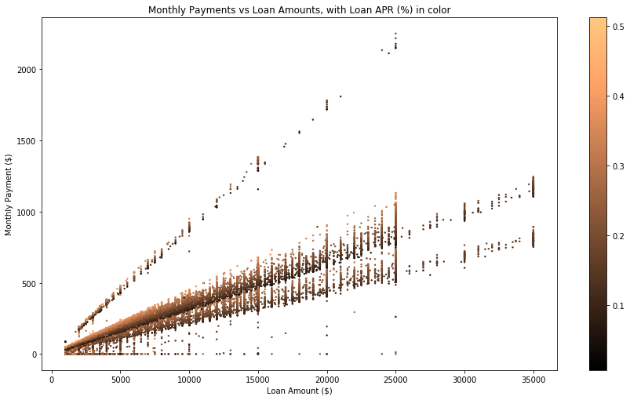

## 5. Conclusion

### Loan Rate (APR)...

- ...is clearly correlated with Risk Assessment Score (inverse relationship)
- ...is clearly correlated with Credit Score (inverse relationship)

If you have a higher credit score, on average, you can get a higher Risk Assessment Score, which can lead to a lower loan rate.

And if you have a lower loan rate, your monthly payments can also be smaller for any given amount borrowed.